# Sección 0 — Configuración e Imports

- Importar todas las librerías
- Definir semilla global: `RANDOM_STATE = 42`
- Configurar estilo de matplotlib/seaborn

```python
import os
import time
import numpy as np
import pandas as pd
import matplotlib.pyplot as plt
import seaborn as sns

from sklearn.preprocessing import LabelEncoder, StandardScaler
from sklearn.impute import SimpleImputer
from sklearn.decomposition import PCA
from sklearn.pipeline import Pipeline
from sklearn.model_selection import train_test_split, StratifiedKFold, GridSearchCV

from sklearn.svm import SVC
from sklearn.naive_bayes import GaussianNB
from sklearn.ensemble import AdaBoostClassifier
from sklearn.tree import DecisionTreeClassifier
from sklearn.discriminant_analysis import LinearDiscriminantAnalysis, QuadraticDiscriminantAnalysis

from sklearn.metrics import accuracy_score, f1_score, precision_score, recall_score
from sklearn.metrics import classification_report, ConfusionMatrixDisplay

import warnings
warnings.filterwarnings('ignore')

# Configuración global
RANDOM_STATE = 42
sns.set_theme(style="whitegrid", context="notebook")
plt.rcParams['figure.figsize'] = (10, 6)
```

# Sección 1 — Carga y Exploración (EDA)

- Cargar CSV con pandas
- Verificar shape, dtypes, valores nulos
- Distribución de clases (gráfica de barras)
- Correlación entre features (heatmap, opcional pero recomendado)
- Separar X (features) e y (label)
- Eliminar columnas no numéricas: `filename`, `label`
- Codificar `y` con LabelEncoder

```
Dataset cargado exitosamente.
Shape: (1000, 60)
```

|  | filename | length | chroma_stft_mean | chroma_stft_var | rms_mean | rms_var | spectral_centroid_mean | spectral_centroid_var | spectral_bandwidth_mean | spectral_bandwidth_var | ... | mfcc16_var | mfcc17_mean | mfcc17_var | mfcc18_mean | mfcc18_var | mfcc19_mean | mfcc19_var | mfcc20_mean | mfcc20_var | label |
| --- | --- | --- | --- | --- | --- | --- | --- | --- | --- | --- | --- | --- | --- | --- | --- | --- | --- | --- | --- | --- | --- |
| 0 | blues.00000.wav | 661794 | 0.350088 | 0.088757 | 0.130228 | 0.002827 | 1784.165850 | 129774.064525 | 2002.449060 | 85882.761315 | ... | 52.420910 | -1.690215 | 36.524071 | -0.408979 | 41.597103 | -2.303523 | 55.062923 | 1.221291 | 46.936035 | blues |
| 1 | blues.00001.wav | 661794 | 0.340914 | 0.094980 | 0.095948 | 0.002373 | 1530.176679 | 375850.073649 | 2039.036516 | 213843.755497 | ... | 55.356403 | -0.731125 | 60.314529 | 0.295073 | 48.120598 | -0.283518 | 51.106190 | 0.531217 | 45.786282 | blues |
| 2 | blues.00002.wav | 661794 | 0.363637 | 0.085275 | 0.175570 | 0.002746 | 1552.811865 | 156467.643368 | 1747.702312 | 76254.192257 | ... | 40.598766 | -7.729093 | 47.639427 | -1.816407 | 52.382141 | -3.439720 | 46.639660 | -2.231258 | 30.573025 | blues |
| 3 | blues.00003.wav | 661794 | 0.404785 | 0.093999 | 0.141093 | 0.006346 | 1070.106615 | 184355.942417 | 1596.412872 | 166441.494769 | ... | 44.427753 | -3.319597 | 50.206673 | 0.636965 | 37.319130 | -0.619121 | 37.259739 | -3.407448 | 31.949339 | blues |
| 4 | blues.00004.wav | 661794 | 0.308526 | 0.087841 | 0.091529 | 0.002303 | 1835.004266 | 343399.939274 | 1748.172116 | 88445.209036 | ... | 86.099236 | -5.454034 | 75.269707 | -0.916874 | 53.613918 | -4.404827 | 62.910812 | -11.703234 | 55.195160 | blues |

5 rows × 60 columns

```
Valores nulos por columna (Máximo encontrado): 0
```

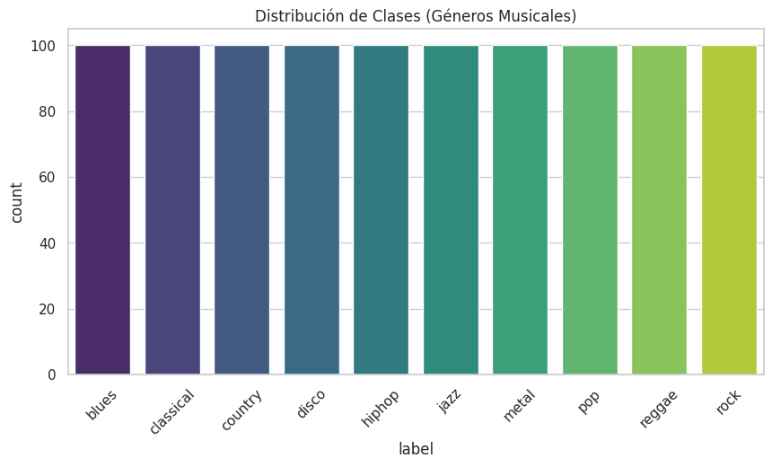

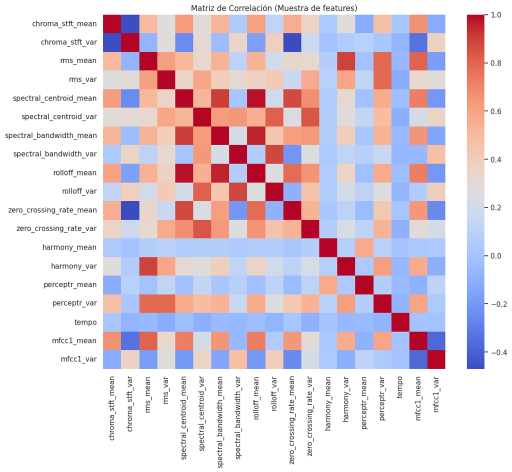

```
Clases codificadas: ['blues' 'classical' 'country' 'disco' 'hiphop' 'jazz' 'metal' 'pop'
 'reggae' 'rock']
Shape de X: (1000, 57)
```

```python
# Cargar datos
try:
    df = pd.read_csv('../data/features_30_sec.csv')
    print("Dataset cargado exitosamente.")
    print(f"Shape: {df.shape}")
except FileNotFoundError:
    print("Error: No se encontró el dataset en '../data/features_30_sec.csv'.")
    print("Asegúrate de descargarlo de Kaggle y colocarlo en la ruta correcta.")
    df = pd.DataFrame()

if not df.empty:
    display(df.head())
    print("\nValores nulos por columna (Máximo encontrado):", df.isnull().sum().max())

    # Distribución de clases
    plt.figure(figsize=(10, 5))
    sns.countplot(data=df, x='label', order=df['label'].value_counts().index, palette='viridis')
    plt.title('Distribución de Clases (Géneros Musicales)')
    plt.xticks(rotation=45)
    plt.show()

    # Heatmap de correlación (Muestra de atributos)
    # Seleccionamos las primeras 20 variables numéricas para que sea legible
    numeric_cols = df.select_dtypes(include=[np.number]).columns[1:20]
    plt.figure(figsize=(12, 10))
    sns.heatmap(df[numeric_cols].corr(), cmap='coolwarm', annot=False)
    plt.title('Matriz de Correlación (Muestra de features)')
    plt.show()

    # Separar X e y
    X = df.drop(columns=['filename', 'length', 'label'], errors='ignore')
    y_raw = df['label']

    # Codificar y
    le = LabelEncoder()
    y = le.fit_transform(y_raw)

    print(f"Clases codificadas: {le.classes_}")
    print(f"Shape de X: {X.shape}")
```

# Sección 2 — Preprocesamiento Unificado (Pipeline)

Este es el núcleo de la equidad experimental. Todos los modelos deben pasar por el mismo transformador. Componentes del pipeline base:

1. Imputación: `SimpleImputer(strategy='mean')`
2. Escalado: `StandardScaler()`

```python
# Data Split
if not df.empty:
    X_train, X_test, y_train, y_test = train_test_split(
        X, y, test_size=0.2, stratify=y, random_state=RANDOM_STATE
    )

    print(f"X_train shape: {X_train.shape}")
    print(f"X_test shape: {X_test.shape}")

# Preprocessor base para el pipeline unificado
# StandardScaler es crucial especialmente para SVM, LDA y KNN.
# Se creará el pipeline completo (preprocessor + estimator) de manera dinámica más adelante.
preprocessor = Pipeline([
    ('imputer', SimpleImputer(strategy='mean')),
    ('scaler', StandardScaler())
])
```

```
X_train shape: (800, 57)
X_test shape: (200, 57)
```

# Sección 3 — Definición de Modelos y Grids de Hiperparámetros

Para cada modelo, definimos el estimador base y su grid de búsqueda.

- M1 — SVM
- M2 — Naive Bayes
- M3 — AdaBoost
- M4 — LDA/QDA

```python
# Diccionario maestro de topologías
models_grids = {
    'SVM': {
        'estimator': SVC(random_state=RANDOM_STATE),
        'param_grid': {
            'classifier__kernel': ['linear', 'rbf', 'poly'],
            'classifier__C': [0.1, 1, 10, 100],
            'classifier__gamma': ['scale', 'auto']
        }
    },
    'NaiveBayes': {
        'estimator': GaussianNB(),
        'param_grid': {
            'classifier__var_smoothing': [1e-9, 1e-7, 1e-5, 1e-3]
        }
    },
    'AdaBoost': {
        # 'SAMME' ya que SAMME.R dejará de ser el default en scikit-learn
        'estimator': AdaBoostClassifier(random_state=RANDOM_STATE),
        'param_grid': {
            'classifier__n_estimators': [50, 100, 200],
            'classifier__learning_rate': [0.5, 1.0, 1.5],
            'classifier__estimator': [
                DecisionTreeClassifier(max_depth=1, random_state=RANDOM_STATE),
                DecisionTreeClassifier(max_depth=2, random_state=RANDOM_STATE)
            ]
        }
    },
    'LDA': {
        'estimator': LinearDiscriminantAnalysis(),
        'param_grid': [
            {'classifier__solver': ['svd'], 'classifier__shrinkage': [None]},
            {'classifier__solver': ['lsqr'], 'classifier__shrinkage': [None, 'auto', 0.1, 0.5]}
        ]
    },
    'QDA': {
        'estimator': QuadraticDiscriminantAnalysis(),
        'param_grid': {
            'classifier__reg_param': [0.0, 0.1, 0.3, 0.5]
        }
    }
}
```

# Sección 4 — Entrenamiento con GridSearchCV + Cross-Validation

- Esquema de CV: `StratifiedKFold(n_splits=5)`
- `scoring = 'f1_macro'`
- `refit = True`

```python
cv = StratifiedKFold(n_splits=5, shuffle=True, random_state=RANDOM_STATE)
scoring = 'f1_macro'

best_models = {}
cv_results = {}

if not df.empty:
    for model_name, info in models_grids.items():
        print(f"\n--- Entrenando {model_name} ---")

        # Pipeline unificado con el estimador final dictado por Grid
        pipeline = Pipeline([
            ('preprocessor', preprocessor),
            ('classifier', info['estimator'])
        ])

        grid_search = GridSearchCV(
            estimator=pipeline,
            param_grid=info['param_grid'],
            cv=cv,
            scoring=scoring,
            n_jobs=-1,
            refit=True
        )

        start_time = time.time()
        grid_search.fit(X_train, y_train)
        training_time = time.time() - start_time

        # Guardar para evaluación posterior
        best_models[model_name] = grid_search.best_estimator_
        cv_results[model_name] = pd.DataFrame(grid_search.cv_results_)

        print(f"Mejor f1_macro (CV): {grid_search.best_score_:.4f}")
        print(f"Mejores hiperparámetros: {grid_search.best_params_}")
        print(f"Tiempo de entrenamiento: {training_time:.2f}s")
```

```
--- Entrenando SVM ---
Mejor f1_macro (CV): 0.7494
Mejores hiperparámetros: {'classifier__C': 100, 'classifier__gamma': 'scale', 'classifier__kernel': 'rbf'}
Tiempo de entrenamiento: 2.44s

--- Entrenando NaiveBayes ---
Mejor f1_macro (CV): 0.5061
Mejores hiperparámetros: {'classifier__var_smoothing': 1e-09}
Tiempo de entrenamiento: 0.05s

--- Entrenando AdaBoost ---
Mejor f1_macro (CV): 0.5663
Mejores hiperparámetros: {'classifier__estimator': DecisionTreeClassifier(max_depth=2, random_state=42), 'classifier__learning_rate': 0.5, 'classifier__n_estimators': 100}
Tiempo de entrenamiento: 6.81s

--- Entrenando LDA ---
Mejor f1_macro (CV): 0.6894
Mejores hiperparámetros: {'classifier__shrinkage': None, 'classifier__solver': 'svd'}
Tiempo de entrenamiento: 0.08s

--- Entrenando QDA ---
Mejor f1_macro (CV): 0.7015
Mejores hiperparámetros: {'classifier__reg_param': 0.3}
Tiempo de entrenamiento: 0.13s
```

# Sección 5 — Evaluación sobre Test Set

Métricas principales, matriz de confusión por modelo y tabla comparativa final.

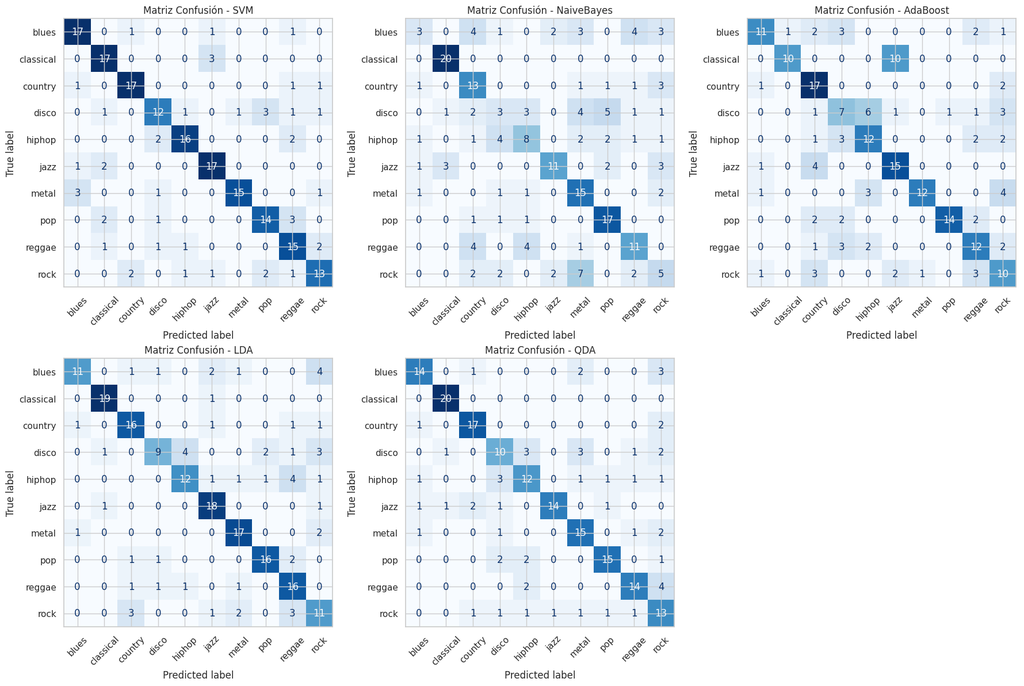

```
======== TABLA COMPARATIVA ========
```

| Model | Accuracy | F1_Macro | Precision_Macro | Recall_Macro | Inference_Time (s) |
| --- | --- | --- | --- | --- | --- |
| SVM | 0.765 | 0.764622 | 0.770414 | 0.765 | 0.007056 |
| QDA | 0.720 | 0.722708 | 0.734250 | 0.720 | 0.001774 |
| LDA | 0.725 | 0.720725 | 0.736976 | 0.725 | 0.001488 |
| AdaBoost | 0.600 | 0.604521 | 0.645569 | 0.600 | 0.007807 |
| NaiveBayes | 0.530 | 0.503561 | 0.510926 | 0.530 | 0.001416 |

```python
results = []

if not df.empty:
    # Preparar subplots para las matrices de confusión (2 filas, 3 columnas -> 5 modelos)
    fig, axes = plt.subplots(2, 3, figsize=(18, 12))
    axes = axes.ravel()

    for i, (model_name, best_pipeline) in enumerate(best_models.items()):

        start_time = time.time()
        y_pred = best_pipeline.predict(X_test)
        inference_time = time.time() - start_time

        # Métricas
        acc = accuracy_score(y_test, y_pred)
        f1 = f1_score(y_test, y_pred, average='macro')
        prec = precision_score(y_test, y_pred, average='macro', zero_division=0)
        rec = recall_score(y_test, y_pred, average='macro')

        results.append({
            'Model': model_name,
            'Accuracy': acc,
            'F1_Macro': f1,
            'Precision_Macro': prec,
            'Recall_Macro': rec,
            'Inference_Time (s)': inference_time
        })

        # Matriz de confusión
        ConfusionMatrixDisplay.from_predictions(
            y_test, y_pred,
            display_labels=le.classes_,
            cmap='Blues',
            ax=axes[i],
            xticks_rotation=45,
            colorbar=False
        )
        axes[i].set_title(f"Matriz Confusión - {model_name}")

    # Limpiamos el último subplot no utilizado (índice 5 de 6)
    if len(best_models) < len(axes):
        for j in range(len(best_models), len(axes)):
            axes[j].axis('off')

    plt.tight_layout()
    plt.savefig('../outputs/figures/confusion_matrices.png', dpi=300)
    plt.show()

    # Tabla comparativa
    results_df = pd.DataFrame(results).set_index('Model').sort_values(by='F1_Macro', ascending=False)
    results_df.to_csv('../outputs/results/model_comparison.csv')

    print("\n======== TABLA COMPARATIVA ========")
    display(results_df)
```

# Sección 6 — Análisis de Fronteras de Decisión

Aplicamos PCA a 2 componentes sobre `X_test` y re-entrenamos el clasificador de cada modelo sobre este espacio reducido para ilustrar el dibujo de fronteras. *(Nota: Reducir dimensiones causa pérdida de separabilidad, es sólo ilustrativo)*

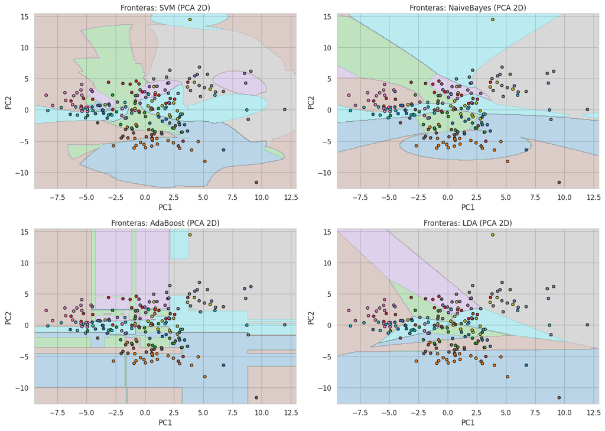

```python
if not df.empty:
    # 1. Transformar a subespacio de visualización
    # Extraemos el preprocesador entrenado del SVM (cualquiera sirve, todos tuvieron la misma data de entrenamiento)
    preprocessor_trained = best_models['SVM'].named_steps['preprocessor']
    X_test_scaled = preprocessor_trained.transform(X_test)

    pca = PCA(n_components=2, random_state=RANDOM_STATE)
    X_pca = pca.fit_transform(X_test_scaled)

    # Malla de puntos
    x_min, x_max = X_pca[:, 0].min() - 1, X_pca[:, 0].max() + 1
    y_min, y_max = X_pca[:, 1].min() - 1, X_pca[:, 1].max() + 1
    xx, yy = np.meshgrid(np.arange(x_min, x_max, 0.1),
                         np.arange(y_min, y_max, 0.1))

    models_to_plot = ['SVM', 'NaiveBayes', 'AdaBoost', 'LDA'] # Excluimos QDA en 2x2
    fig, axes = plt.subplots(2, 2, figsize=(14, 10))
    axes = axes.ravel()

    for i, m_name in enumerate(models_to_plot):
        if m_name in best_models:
            # Recuperar estimador base real (clonándolo o usando el mismo y re-entrenando)
            clf = best_models[m_name].named_steps['classifier']

            # Ajuste de demostración sobre PCA
            clf.fit(X_pca, y_test)

            # Predicción para la grilla
            Z = clf.predict(np.c_[xx.ravel(), yy.ravel()])
            Z = Z.reshape(xx.shape)

            axes[i].contourf(xx, yy, Z, alpha=0.3, cmap='tab10')
            axes[i].scatter(X_pca[:, 0], X_pca[:, 1], c=y_test, s=20, edgecolor='k', cmap='tab10')
            axes[i].set_title(f'Fronteras: {m_name} (PCA 2D)')
            axes[i].set_xlabel('PC1')
            axes[i].set_ylabel('PC2')

    plt.tight_layout()
    plt.savefig('../outputs/figures/decision_boundaries.png', dpi=300)
    plt.show()
```

# Sección 7 — Benchmarking Final (Phase 3)